# Data Privacy Survey

Challenges and needs of privacy-related services for research at Utrecht University

Dorien Huijser, Research Data Management Support, Utrecht University

Neha Moopen, Research Data Management Support, Utrecht University

Version: 2022-09-22

Abstract

In the second quarter of 2022, Utrecht University (UU) Research Data Management Support (RDM Support) sent out a survey among all scientific personnel at UU: the Data Privacy Survey. The aim of this survey was to investigate 1) How UU researchers currently deal with personal data in research, 2) What challenges they run into when handling personal data in research, and 3) How support at UU can improve their services concerning personal data in research. The results show that most researchers know to take into account privacy in their projects. However, there are vast differences in knowledge on this topic, as well as confusion on topics such as data sharing, anonymisation, and the administrative requirements surrounding privacy. Taken together, the survey shows that researchers could benefit from research support that is more visible in the organisation and more hands-on (i.e., advise that is immediately applicable instead of more general). Additionally, more awareness of the most important privacy-related topics, and how to deal with them in research seems desirable, both for newly employed and existing researchers. Finally, many researchers indicate to experience a high administrative burden that is partly caused by privacy-related documentation before starting a project. Finding a way to decrease this burden while still complying with legal and policy regulations will likely help to increase compliance and help researchers focus on performing high-quality research.

# Introduction

Scientific research often includes some form of personal data. The amount of personal data that is processed in research is likely underestimated, as researchers may be unaware of what personal data are or whether they are being collected. With the implementation of the General Data Protection Regulation (GDPR) in 2018, stricter legal requirements apply to handling personal data and its sharing and publication. In our own experience, the number and complexity of questions on handling personal data in scientific research at Utrecht University (UU) is increasing.

Our premise at [Research Data Management Support](https://uu.nl/rdm) (RDM Support) is to assist researchers with any issues surrounding the management of their research data, including research data that contains personal data. To understand how we can best help researchers with their privacy-related questions and needs, we wanted to investigate:

1. To what extent are UU researchers aware of privacy legislation and practices?
2. What data privacy issues do UU researchers typically run into?
3. What support do UU researchers need to handle personal data?

To answer these questions, we set up an online survey and planned one-on-one meetings with a selection of UU researchers. This report describes our methods, results and the future steps that data support at UU can take to improve their services concerning privacy in research.

This survey was part of a larger project at UU, the [Data Privacy Project](https://utrechtuniversity.github.io/dataprivacyproject/)[^1]. This project is a data support effort within UU that aims to provide actionable and FAIR (Findable, Accessible, Interoperable, Reusable) information and tools for researchers to handle personal data in their research.

# Methods

## Survey questions

The Data Privacy Survey was created by the project coordinators (DH, NM) with input from a wide variety of experts, consisting of privacy experts, data managers, data consultants, and IT staff (e.g., information security, research engineering). The survey consisted of 19-23 questions (the exact number differing depending on given answers), which were separated into 5 sections:

1. **About you and your research**: 5 questions about the faculty, department, position, and type of (personal) data the researcher works with.
2. **Measures and documents**: 4-6 questions about researchers’ familiarity and use of privacy-related measures (e.g., processing register, Data Privacy Impact Assessment, encryption, pseudonymisation, etc.), data storage, and informed consent forms.
3. **Data sharing, archiving and publication**: 3-4 questions about researchers’ data sharing and publishing practices.
4. **Finding support**: 3-4 questions about the awareness of several data support channels.
5. **Improving our services**: 4 questions about researchers’ challenges, needs, and suggestions to improve UU’s data privacy support.

The estimated 10 minute duration of the survey in advance proved to be relatively accurate: respondents spent a median of 8.4 minutes on the survey (although there was a very large variation; range: 0.4 minutes - 5.1 days).

## Procedure online survey

The survey was created in Qualtrics and distributed from March 21st, 2022 onwards via several communication channels to reach as many UU researchers as possible:

- An [email](https://utrechtuniversity.github.io/dataprivacyproject/20220321-data-privacy-survey.html) was sent to all academic staff at UU through central communication channels. The reasoning was that this would be the most effective way to reach as many UU researchers as possible - taking for granted that we would likely miss a small part of non-academic personnel also involved in research in some way.
- A mention in several Faculty newsletters.
- Social media messages (e.g., on [Twitter](https://twitter.com/RDMsupportUU/status/1517390979707412481)).
- A [news item](https://intranet.uu.nl/en/news/news-items/survey-better-support-for-handling-privacy-sensitive-data-in-research) on the UU intranet.
- Via data support colleagues, who were asked to point researchers they were in contact with to the survey.

Researchers could decide voluntarily whether they wanted to participate in the survey. All results reported here are from researchers who provided their active consent, worked at Utrecht University and indicated to work with some type of research data.

## Online survey respondents

### UU-wide

The survey was filled out by 175 UU researchers. As can be seen in the figure below, we received responses from each UU faculty, but the distribution was not equal: the faculties of Science and Social and Behavioural Sciences were overrepresented, whereas the responses of the Faculty of Geosciences and the Faculty of Medicine were rather low. This can be explained by the mere size of the faculties (e.g., the faculty of Science is UU’s largest faculty), but also by the types of research performed there. For example, research performed at the faculty of Geosciences is largely involved with natural scientific data, rather than data from or relating to humans. The Faculty of Medicine, then, is located at the University Medical Center Utrecht (UMCU) and is not of primary interest for the current survey, which was sent to UU researchers only. A small selection of respondents indicated to work at another part of the organisation, being mainly University College Utrecht and the University Corporate Office.

Most of the survey respondents were relatively early career researchers (PhDs, junior researchers and postdoctoral researchers). We suspect that this is because 1) there simply are more people in these positions than there are in the others, and 2) early-career researchers may experience a greater need for support with respect to handling personal data.

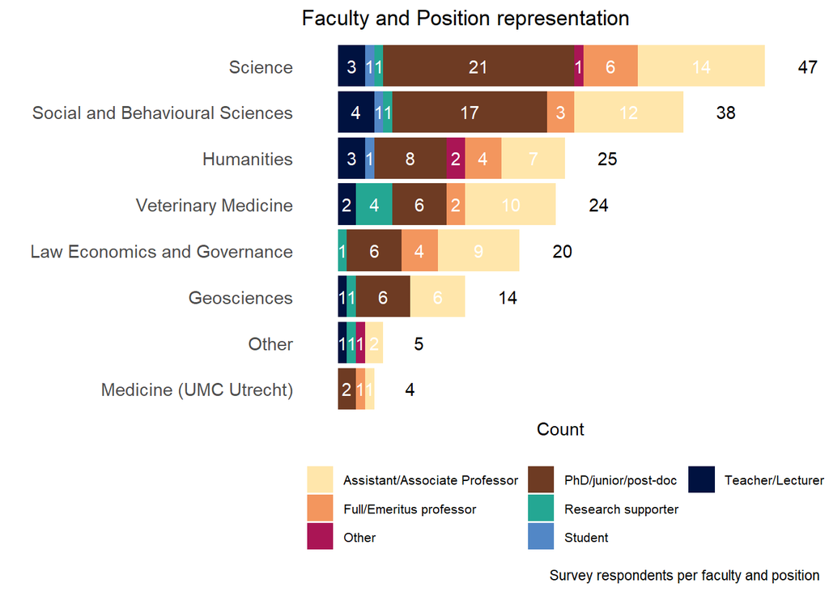

### Science

There were 44 respondents from the Science faculty in the online survey. It took them a median of 5.7 minutes to complete it (ranging from 0.6 minutes to 5.1 days). In the graph below, the representation of each department within the Science faculty is visualised.

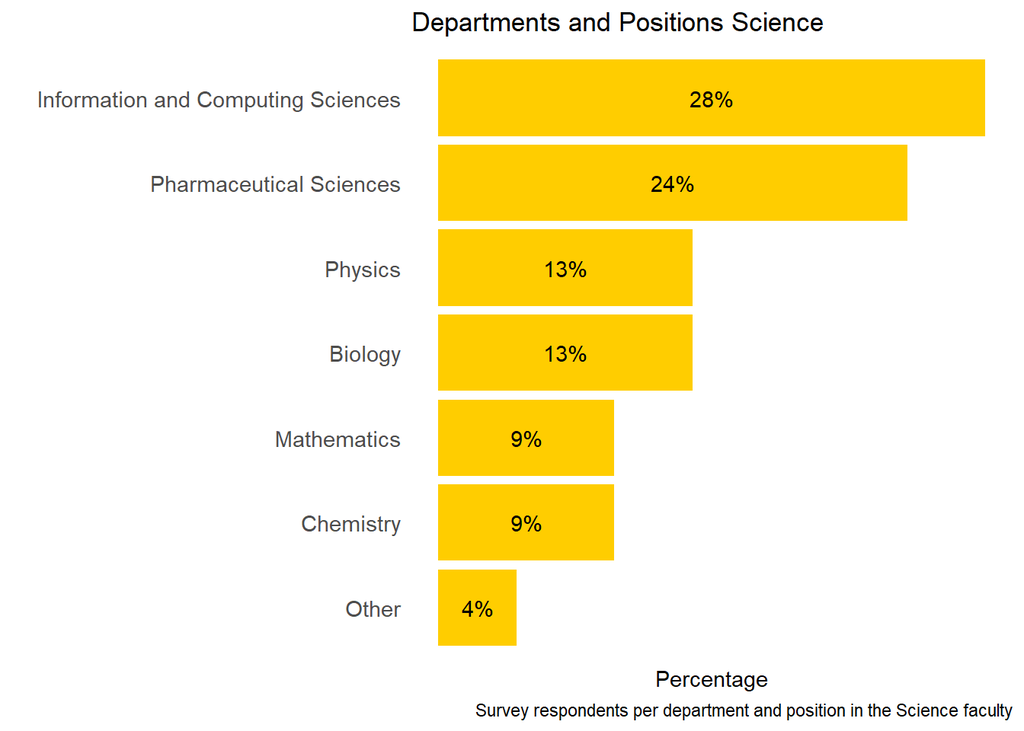

Most respondents in the online survey seemed to come from the Information and Computing Sciences (ICS) and Pharmaceutical Sciences departments, and were relatively early career researchers (PhD/junior/postdoc researcher, assistant/associate professor). This makes sense, as more personal data is likely processed in the fields of ICS and pharmaceuticals, compared to, for example, mathematics.

### FSBS

There were 40 respondents from the Faculty of Social and Behavioural Sciences (FSBS) in the online survey. It took them a median of 9.1 minutes to complete it (ranging from 0.4 minutes to 0.3 days). In the graph below, the representation of each department within FSBS is visualised.

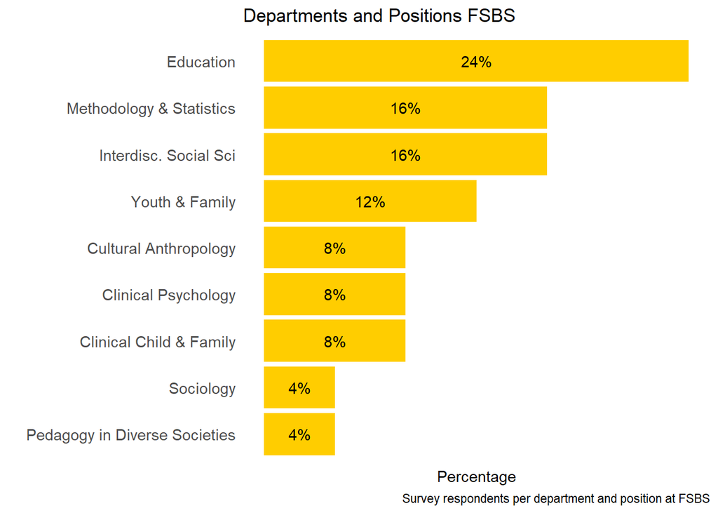

Most respondents in the online survey seemed to come from the Education department, although closely followed by Methodology and Statistics and Interdisciplinary Social Sciences. Additionally, respondents from the Faculty of Social and Behavioural Sciences were mostly either PhD/junior/post-doc researcher or Assistant/Associate professors.

### Humanities

There were 27 respondents from the Faculty of Humanities in the online survey. It took them a median of 8.5 minutes to complete it (ranging from 0.9 minutes to 1.3 days). In the graph below, the representation of each department within the Faculty of Humanities is visualised.

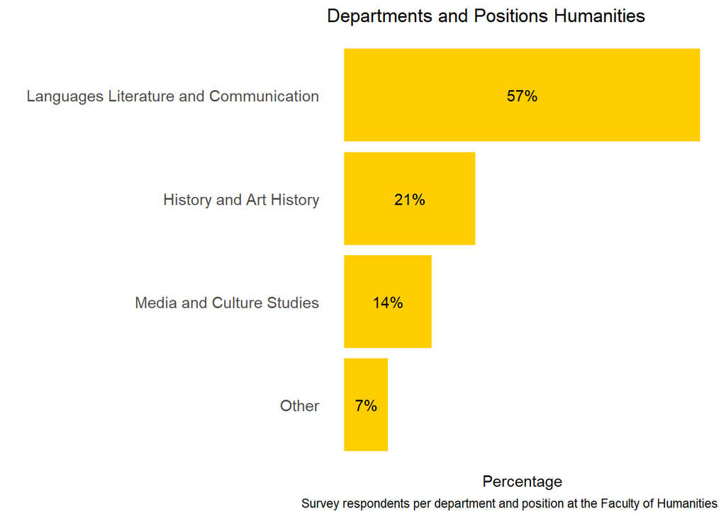

The majority of Humanities researchers responding to the survey were employed at the department of Languages, Literature and Communicaiton. This makes sense, as likely a lot of personal data is processed there. Position-wise, there was quite some variability, although most respondents indicated to be either PhD/junior/postdoc researcher or Assistant/Associate Professor.

### Veterinary Medicine

There were 22 respondents from the Faculty of Veterinary Medicine in the online survey. It took them a median of 10.5 minutes to complete it (ranging from 1.4 minutes to 0.2 days). In the graph below, the representation of each department within the Faculty of Veterinary Medicine is visualised.

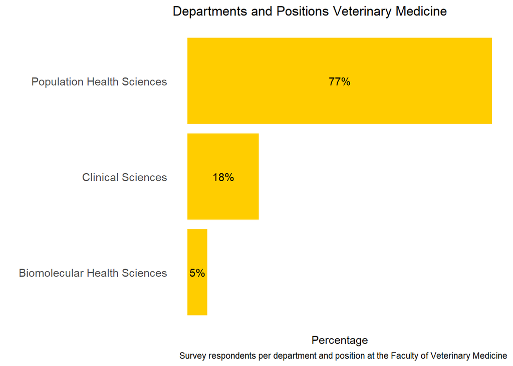

### LEG

There were 21 respondents from the Faculty of Law, Economics, and Governance (LEG) in the online survey. It took them a median of 10.1 minutes to complete it (ranging from 3.5 minutes to 0.9 days). In the graph below, the representation of each department within the Faculty of Law, Economics, and Governance (LEG) is visualised.

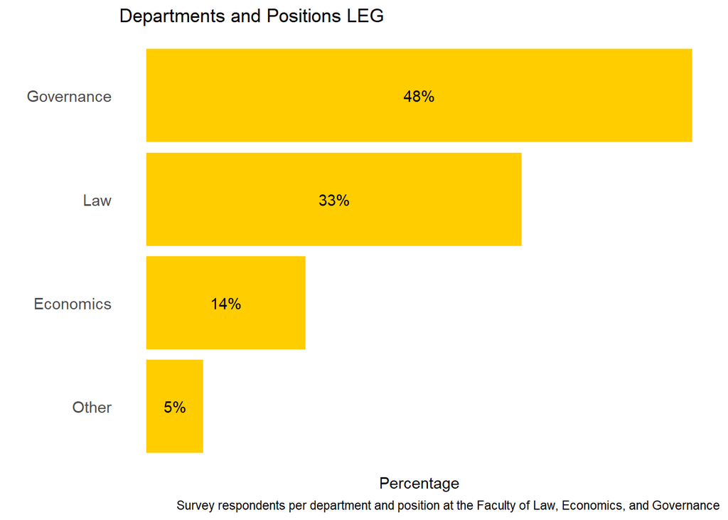

### Geo

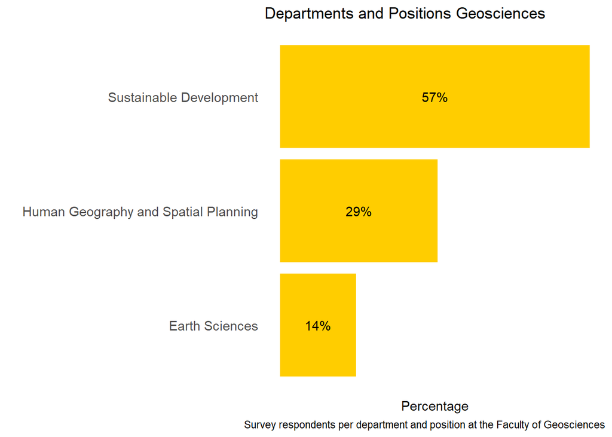

From the Geosciences faculty, most respondents were employed at the department of Sustainable Development, followed by Human Geography and Spatial Planning. Respondents were mostly PhD/junior/postdoc researchers and Assistant/Associate professors. Earth Sciences did not have many respondents, which makes sense as it is less likely that personal data are being processed there in the research context.

## One-on-one meetings

Besides the online survey, we organised one-on-one meetings with researchers, to hear about their personal experiences, challenges and needs concerning the handling of personal data in their research. Survey respondents could voluntarily leave their email address at the end of the survey to be contacted by us. These meetings were semi-structured and revolved around the following questions:

- What made you leave your email address in the Data Privacy Survey? Related: What are your general experiences in handling personal data in research?
- Which difficulties do you run into when handling personal data?
- What support would you need to help you handle personal data in your research?
- Do you have a concrete need for support at the moment?

All of the one-on-one meetings were conducted online and took approximately 30 minutes. During the meetings, one of the project coordinators (DH) was always present, together with either the other project coordinator (NM) or the relevant faculty privacy officer. Before the privacy officer was invited to the meeting, the researcher’s consent to do so was always obtained first.

### UU-wide

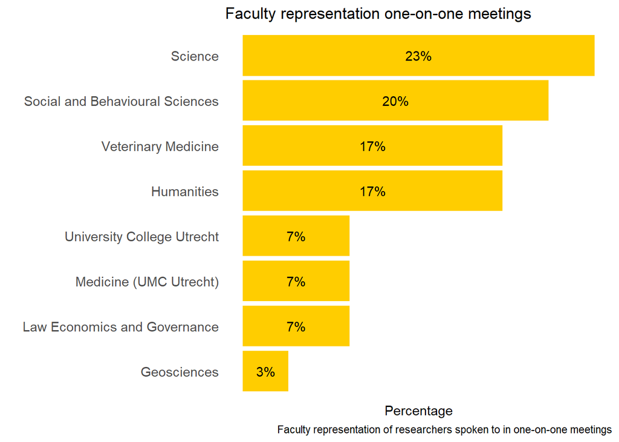

### Science

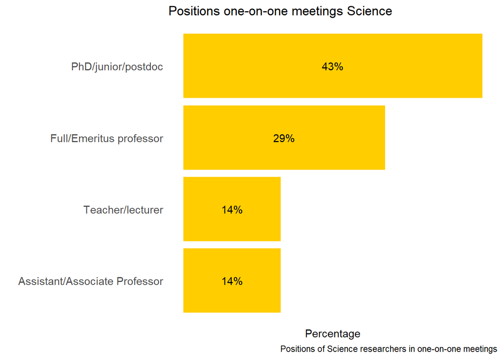

### FSBS

From the survey respondents, 9 researchers from the faculty of Social and Behavioural Sciences (FSBS) left their email address to be contacted, although not all researchers indicated to be willing to meet with us when contacted. So far, 6 online meetings have been conducted, most of them with a privacy officer present. Below, the division over positions can be seen for all interviewees from the faculty of Social and Behavioural Sciences (FSBS).

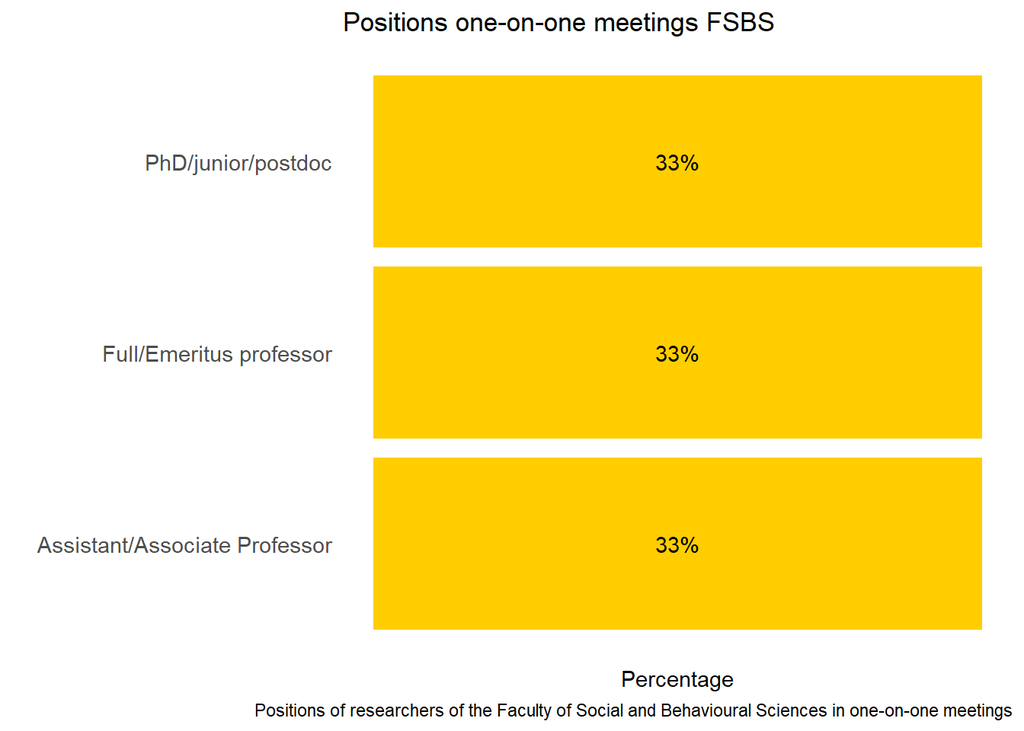

### Humanities

From the survey respondents, 7 researchers from the Humanities faculty left their email address to be contacted, although not all researchers indicated to be willing to meet with us when contacted. So far, 5 online meetings have been conducted, all of them with a privacy officer present. Below, the division over positions can be seen for all interviewees from the Humanities faculty.

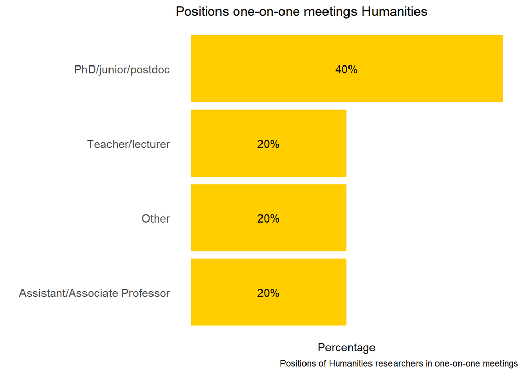

### Veterinary Medicine

From the survey respondents, 7 researchers from the faculty of Veterinary Medicine left their email address to be contacted, although not all researchers indicated to be willing to meet with us when contacted. So far, 5 online meetings have been conducted, most of them with a privacy officer present. Below, the division over positions can be seen for all interviewees from the faculty of Veterinary Medicine.

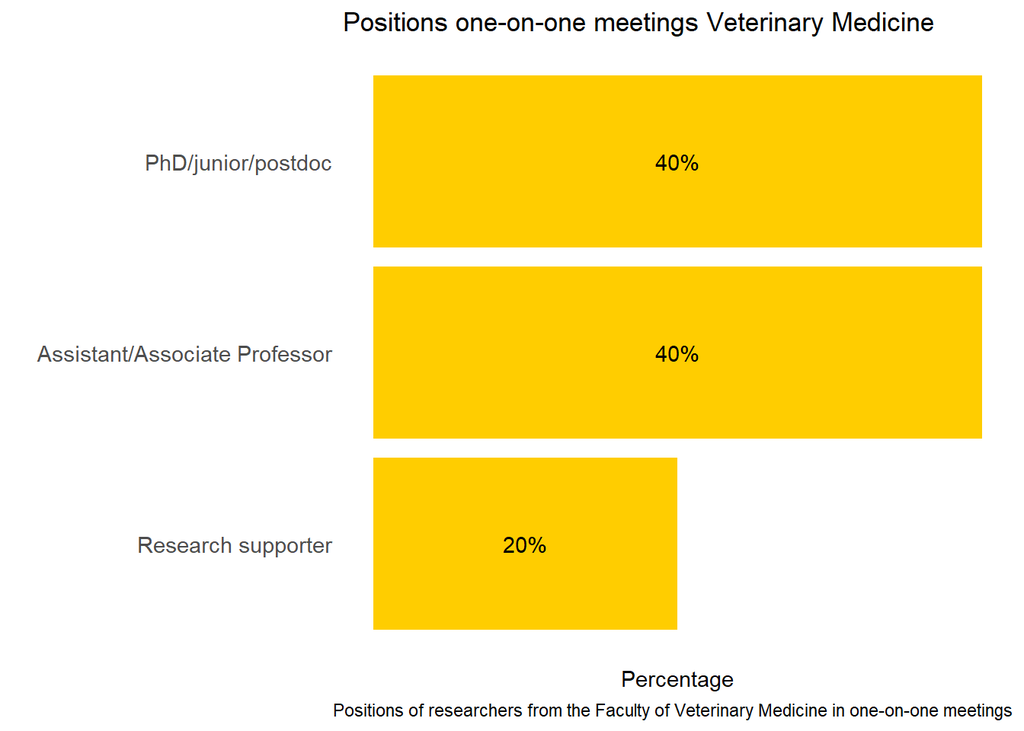

### LEG

From the survey respondents, 7 researchers from the faculty of Law, Economics, and Governance (LEG) left their email address to be contacted, although not all researchers indicated to be willing to meet with us when contacted. So far, 2 online meetings have been conducted, most of them with a privacy officer present. Below, the division over positions can be seen for all interviewees from the faculty of Law, Economics, and Governance (LEG).

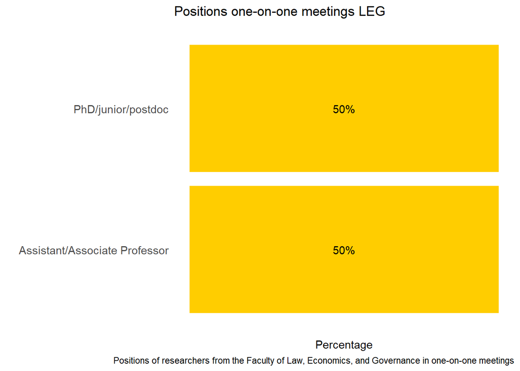

### Geo

From the survey respondents, 1 researchers from the Geosciences faculty left their email address to be contacted, although not all researchers indicated to be willing to meet with us when contacted. So far, 1 online meetings have been conducted. Below, the division over positions can be seen for all interviewees from the Geosciences faculty.

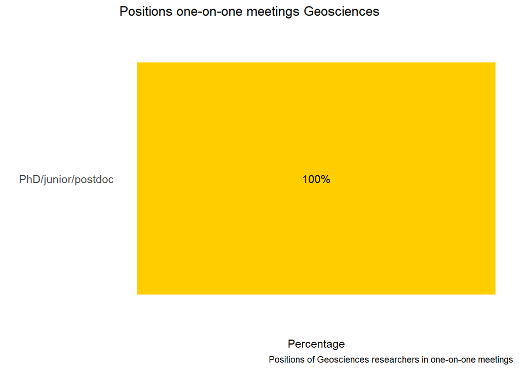

## Analysis

From the raw Qualtrics output, we first cleaned and split the data into different data files (cleaned and closed survey responses, open text responses, email addresses, see the pseudonymise-data.R script for details). Both the open text responses and the notes made during the one-on-one meetings were separately and manually scored to enable the extraction of action points.

Below we report on the descriptive statistics or summaries from most of the survey questions. As we did not formulate hypotheses, no statistical analyses were performed.

## Data and material availability

All survey-related documentation can be found in the [dedicated survey repository](https://github.com/UtrechtUniversity/dataprivacysurvey). It contains:

- The [full survey](https://utrechtuniversity.github.io/dataprivacysurvey/assets/survey-questions-qualtrics.pdf)
- The survey’s [privacy statement](https://utrechtuniversity.github.io/dataprivacysurvey/assets/survey-privacy-statement.pdf)
- The [scripts used to clean the data and write this report](https://github.com/UtrechtUniversity/dataprivacysurvey/tree/main/src)

As the dataset contains personal information (demographic information, open text responses, email addresses, etc.), and no consent was obtained to share those details, we are unable to share them in this repository.

# Results

## Types of research data

### UU-wide

To investigate the types of research that was represented in the sample, we asked which types of data, and specifically which types of *personal* data the respondents worked with. Most respondents indicated to use tabular, textual, code and audio data as their primary research data format. In terms of *personal* data types, contact information, demographic information and direct identifiers were most common among the respondents. This can be either because these are the types of personal data that are indeed most common, but possibly also because researchers mostly recognise these types of data as being personal data.

**Types of data used**

| Datatype | Frequency |
| --- | --- |
| Tabular data | 124 (70.9%) |
| Textual data | 106 (60.6%) |
| Code/theoretical models | 60 (34.3%) |
| Audio data | 56 (32%) |
| Video data | 39 (22.3%) |
| Images | 38 (21.7%) |
| Bio-medical samples and data | 28 (16%) |
| Physiological measurements | 27 (15.4%) |
| Geographical data | 25 (14.3%) |
| Physical samples | 11 (6.3%) |
| Other | 8 (4.6%) |

**Types of *personal* data used**

| Personal Datatype | Frequency |
| --- | --- |
| Demographic information | 102 (58.3%) |
| Contact information | 81 (46.3%) |
| Direct identifiers | 66 (37.7%) |
| Sensitive demographic information | 35 (20%) |
| Human behaviour | 32 (18.3%) |
| Derived personal data | 30 (17.1%) |
| Health/physical information | 25 (14.3%) |
| None | 18 (10.3%) |
| Other | 11 (6.3%) |
| Sensitive direct identifiers | 9 (5.1%) |

When comparing faculties, it appears that most personal data is processed in the faculties of Social and Behavioural Sciences (FSBS), although the faculties of Science and Veterinary Medicine also seem to process quite some personal data. In the tabs, we look further into the types of (personal) data processed within each faculty.

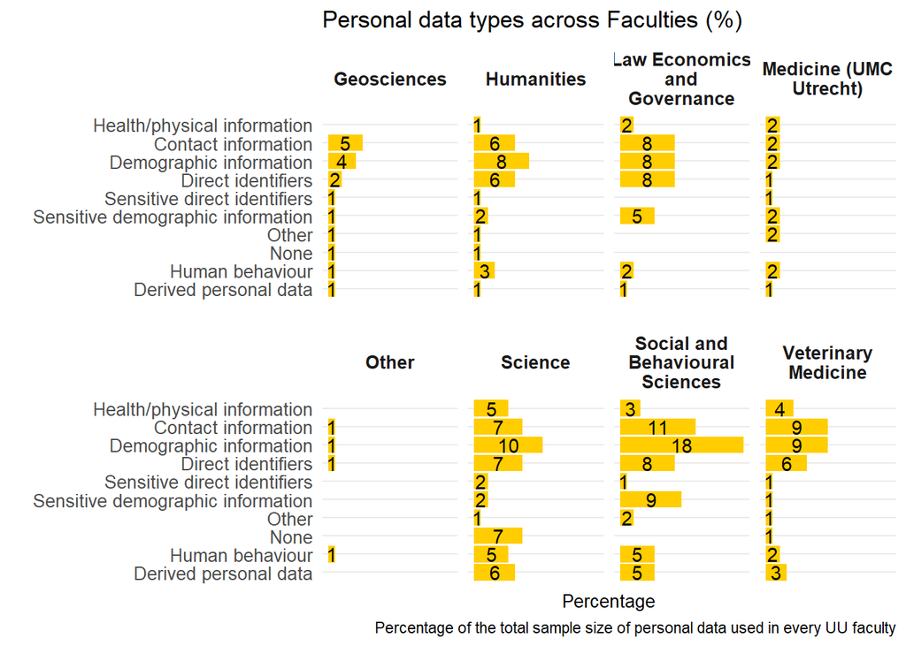

### Science

As with the university-wide data, researchers from the Science faculty indicated that they also most often used tabular data, textual data and code/theoretical models in their research. The same goes for the types of *personal* data: the same top-3 types are used here as in the entire university (demographic information, contact information, direct identifiers).

**Types of data used**

| Datatype | Frequency |
| --- | --- |
| Tabular data | 34 (77.3%) |
| Textual data | 27 (61.4%) |
| Code/theoretical models | 24 (54.5%) |
| Images | 13 (29.5%) |
| Video data | 9 (20.5%) |
| Bio-medical samples and data | 8 (18.2%) |
| Audio data | 8 (18.2%) |
| Physical samples | 6 (13.6%) |
| Physiological measurements | 5 (11.4%) |
| Geographical data | 4 (9.1%) |
| Other | 2 (4.5%) |

**Types of *personal* data used**

| Personal Datatype | Frequency |
| --- | --- |
| Demographic information | 17 (9.7%) |
| Direct identifiers | 13 (7.4%) |
| Contact information | 13 (7.4%) |
| None | 12 (6.9%) |
| Derived personal data | 11 (6.3%) |
| Human behaviour | 9 (5.1%) |
| Health/physical information | 8 (4.6%) |
| Sensitive direct identifiers | 4 (2.3%) |
| Sensitive demographic information | 4 (2.3%) |
| Other | 2 (1.1%) |

As a large part of the researchers from the Science faculty indicated not to use *any* personal data whatsoever in their research, it may be useful to investigate in which departments these researchers work. In the figure below, the division of personal data types per Science department is plotted. As can be expected, the departments of Biology, Physics and Mathematics do not seem to process much personal data, whereas in the Information and Computing Sciences and Pharmaceutical Sciences departments, the most personal data is processed. This makes sense considering the types of research performed in these departments.

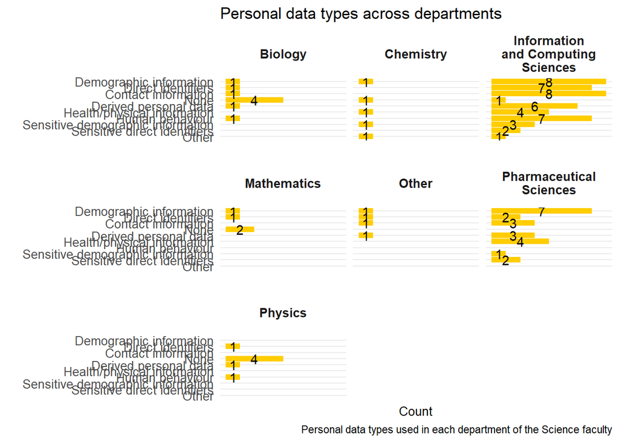

### FSBS

As with the university-wide data, researchers from the faculty of Social and Behavioural Sciences (FSBS) indicated that they also most often used tabular data, textual data and code/theoretical models in their research. The same goes for the types of *personal* data: demographic and contact information are most often used. Interestingly, sensitive demographic information is used much more relative to the UU-wide responses.

**Types of data used**

| Datatype | Frequency |
| --- | --- |
| Tabular data | 32 (80%) |
| Textual data | 17 (42.5%) |
| Code/theoretical models | 12 (30%) |
| Audio data | 12 (30%) |
| Video data | 10 (25%) |
| Physiological measurements | 7 (17.5%) |
| Geographical data | 6 (15%) |
| Other | 4 (10%) |
| Bio-medical samples and data | 4 (10%) |
| Images | 3 (7.5%) |

**Types of *personal* data used**

| Personal Datatype | Frequency |
| --- | --- |
| Demographic information | 32 (18.3%) |
| Contact information | 19 (10.9%) |
| Sensitive demographic information | 15 (8.6%) |
| Direct identifiers | 14 (8%) |
| Human behaviour | 8 (4.6%) |
| Derived personal data | 8 (4.6%) |
| Health/physical information | 5 (2.9%) |
| Other | 3 (1.7%) |
| Sensitive direct identifiers | 1 (0.6%) |

When comparing the types of personal data across departments of the faculty, the departments of Sociology and Cultural Anthropology seem to process the least amount of personal data - although these departments may also simply be underrepresented in the survey sample. Most other departments process quite some personal data, as can be expected from a faculty of which the research focuses almost exclusively on humans.

[figure not shown]

### Humanities

As with the university-wide data, researchers from the faculty of Humanities indicated that they also most frequently used tabular data, textual data and audio data in their research. The same goes for the types of *personal* data: the same top-3 types are present here as in the entire university (demographic information, contact information, direct identifiers).

**Types of data used**

| Datatype | Frequency |
| --- | --- |
| Textual data | 18 (66.7%) |
| Tabular data | 13 (48.1%) |
| Audio data | 12 (44.4%) |
| Video data | 6 (22.2%) |
| Images | 5 (18.5%) |
| Code/theoretical models | 4 (14.8%) |
| Physiological measurements | 2 (7.4%) |
| Bio-medical samples and data | 2 (7.4%) |

**Types of *personal* data used**

| Personal Datatype | Frequency |
| --- | --- |
| Demographic information | 14 (8%) |
| Direct identifiers | 11 (6.3%) |
| Contact information | 10 (5.7%) |
| Human behaviour | 5 (2.9%) |
| Sensitive demographic information | 4 (2.3%) |
| Other | 2 (1.1%) |
| None | 2 (1.1%) |
| Derived personal data | 2 (1.1%) |
| Sensitive direct identifiers | 1 (0.6%) |
| Health/physical information | 1 (0.6%) |

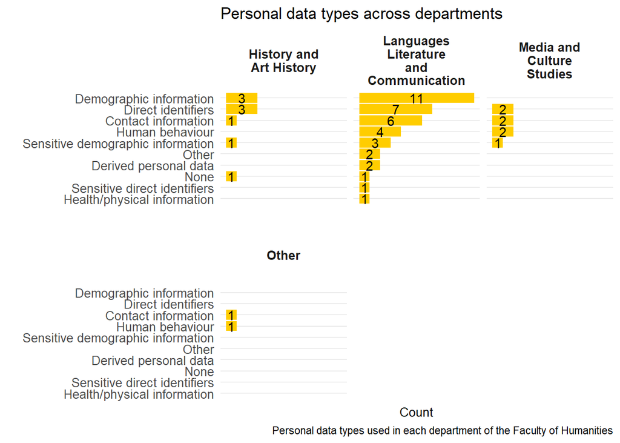

### Veterinary Medicine

When comparing the types of data that researchers at the Faculty of Veterinary Medicine work with, it is clear that researchers at this faculty work with slightly different types of data, i.e. biological and physiological data are more common among these researchers. Despite this, the most frequent types of personal data do correspond well to the university-wide numbers: demographic information, direct identifiers and contact information are also the most common types of personal data researchers at this faculty seem to deal with.

**Types of data used**

| Datatype | Frequency |
| --- | --- |
| Tabular data | 19 (86.4%) |
| Bio-medical samples and data | 13 (59.1%) |
| Textual data | 12 (54.5%) |
| Physiological measurements | 12 (54.5%) |
| Images | 10 (45.5%) |
| Code/theoretical models | 10 (45.5%) |
| Video data | 9 (40.9%) |
| Geographical data | 6 (27.3%) |
| Audio data | 4 (18.2%) |
| Physical samples | 3 (13.6%) |
| Other | 1 (4.5%) |

**Types of *personal* data used**

| Personal Datatype | Frequency |
| --- | --- |
| Demographic information | 15 (8.6%) |
| Contact information | 15 (8.6%) |
| Direct identifiers | 11 (6.3%) |
| Health/physical information | 7 (4%) |
| Derived personal data | 5 (2.9%) |
| Human behaviour | 3 (1.7%) |
| Sensitive direct identifiers | 2 (1.1%) |
| None | 2 (1.1%) |
| Sensitive demographic information | 1 (0.6%) |
| Other | 1 (0.6%) |

When looking at each department separately, it is clear that researchers in the department of Population Health Sciences process the large majority of the personal data within the faculty. Of course, it may also be possible that this department was simply more represented in the survey than the other departments.

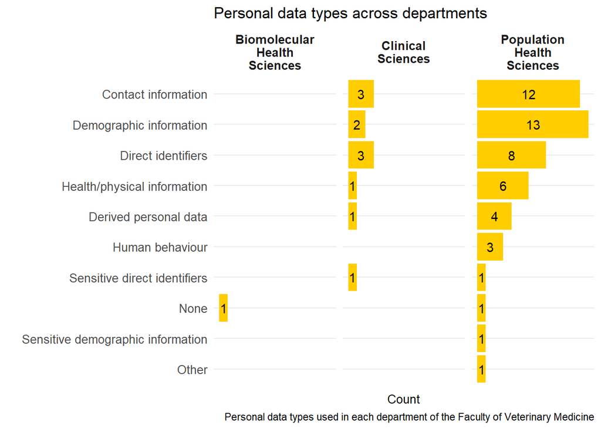

### LEG

As with the university-wide data, researchers from the faculty of Law, Economics and Governance (LEG) indicated that they also most frequently used tabular data, textual data and audio data in their research. The same goes for the types of *personal* data: the same top-3 types are present here as in the entire university (demographic information, contact information, direct identifiers).

**Types of data used**

| Datatype | Frequency |
| --- | --- |
| Textual data | 17 (81%) |
| Tabular data | 13 (61.9%) |
| Audio data | 12 (57.1%) |
| Images | 3 (14.3%) |
| Video data | 2 (9.5%) |
| Geographical data | 2 (9.5%) |
| Code/theoretical models | 1 (4.8%) |

**Types of *personal* data used**

| Personal Datatype | Frequency |
| --- | --- |
| Direct identifiers | 14 (8%) |
| Demographic information | 14 (8%) |
| Contact information | 14 (8%) |
| Sensitive demographic information | 8 (4.6%) |
| Human behaviour | 3 (1.7%) |
| Health/physical information | 3 (1.7%) |
| Derived personal data | 2 (1.1%) |

When looking at the different departments within the faculty, researchers in the department of Governance seem to process personal data the most often, followed by the department of Law. Of course, it is possible that the other departments process more personal data than the respondents indicated.

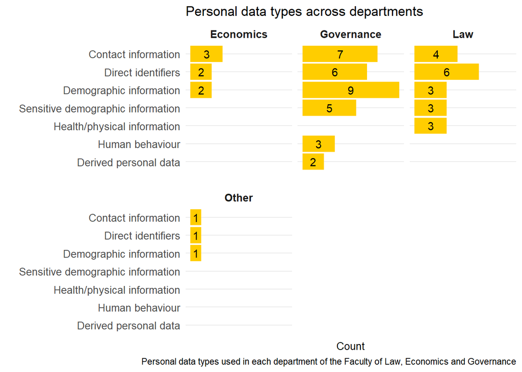

### Geo

As with the university-wide data, researchers from the faculty of Geosciences indicated that they also most frequently used textual and tabular data. However, in contrast to the university-wide data, they are followed by geographical data and code/theoretical models. This is to be expected considering the faculty. In terms of *personal* data, however, the same top-3 types are present here as in the entire university (demographic information, contact information, direct identifiers).

**Types of data used**

| Datatype | Frequency |
| --- | --- |
| Textual data | 11 (78.6%) |
| Tabular data | 10 (71.4%) |
| Geographical data | 7 (50%) |
| Code/theoretical models | 7 (50%) |
| Audio data | 4 (28.6%) |
| Video data | 2 (14.3%) |
| Physical samples | 2 (14.3%) |
| Images | 2 (14.3%) |

**Types of *personal* data used**

| Personal Datatype | Frequency |
| --- | --- |
| Contact information | 9 (5.1%) |
| Demographic information | 7 (4%) |
| Direct identifiers | 4 (2.3%) |
| None | 2 (1.1%) |
| Human behaviour | 2 (1.1%) |
| Derived personal data | 2 (1.1%) |
| Sensitive direct identifiers | 1 (0.6%) |
| Sensitive demographic information | 1 (0.6%) |
| Other | 1 (0.6%) |

When comparing departments, it becomes immediately clear that most personal data seems to be processed in the department of Sustainable Development, and some also in the Human Geography and Spatial Planning department. This makes sense, as the research performed at the third department (Earth sciences) usually does not focus on human behaviour and thus does not involve much personal data, if any.

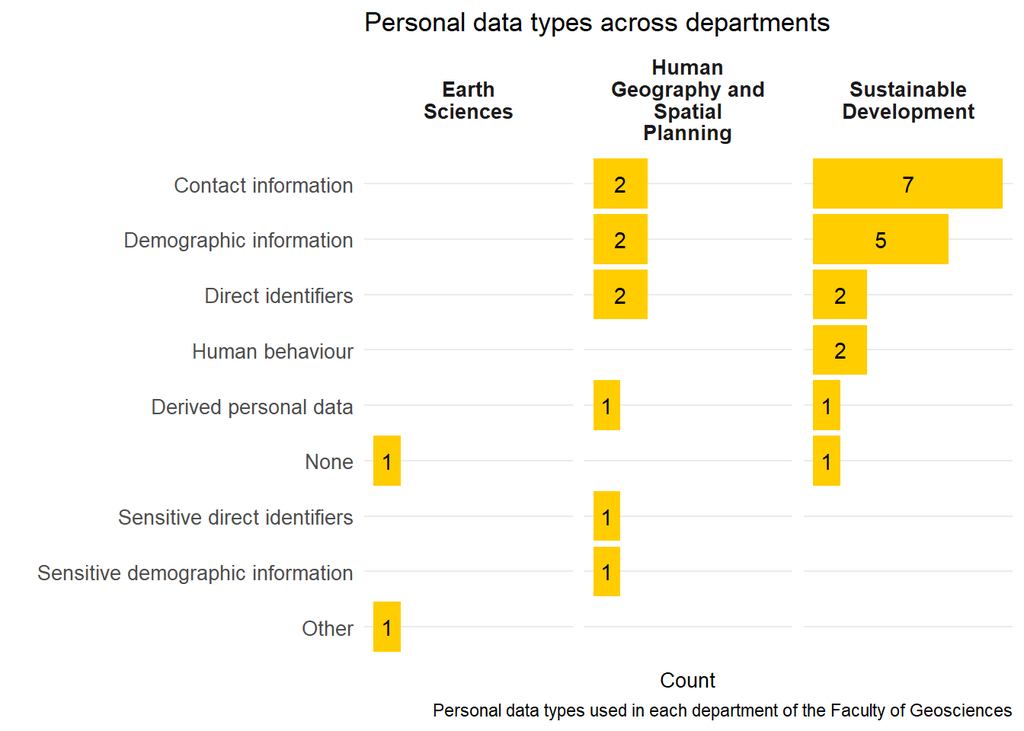

## Current practices

The first part of the survey addressed the researchers’ current practices in handling personal data in their research.

### Protective measures

#### UU-wide

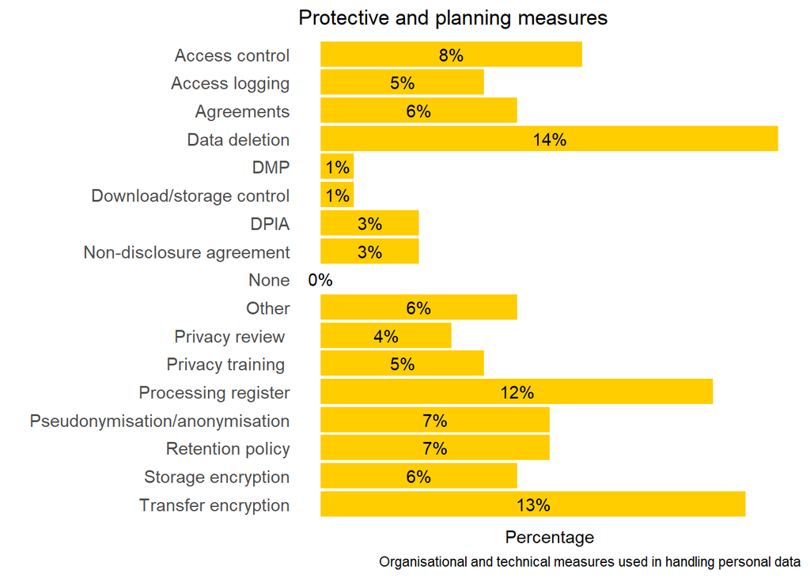

#### Science

Protective measures for Science faculty

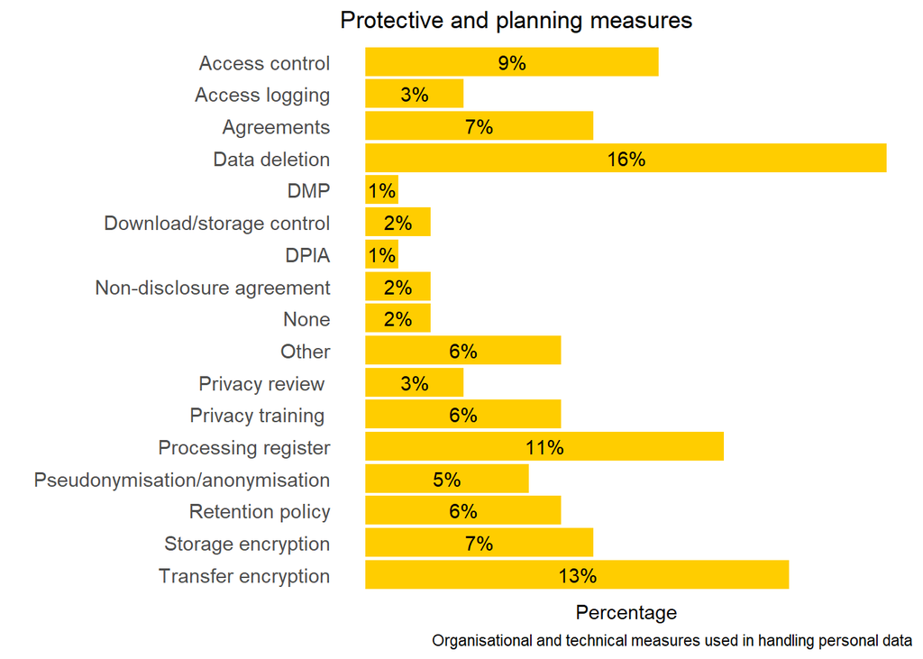

#### FBSB

Protective measures for the Faculty of Social and Behavioural Sciences (FSBS)

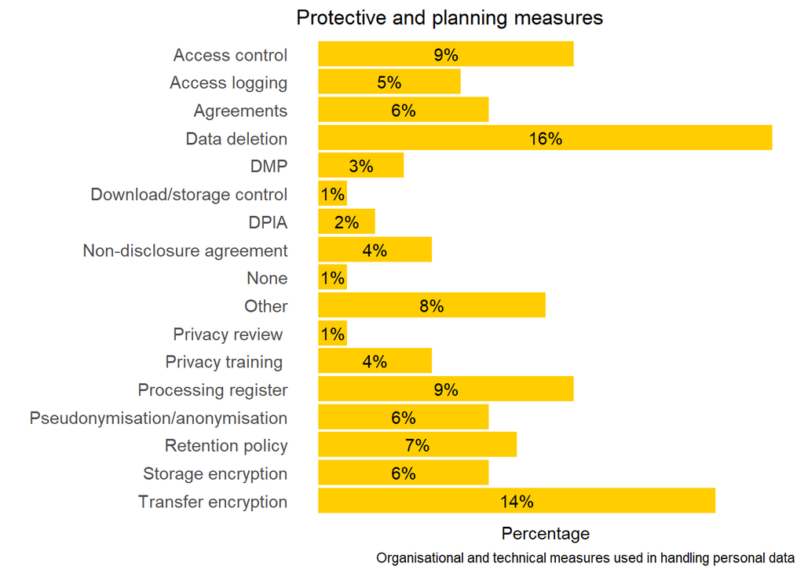

#### Humanities

Protective measures for the Faculty of Humanities.

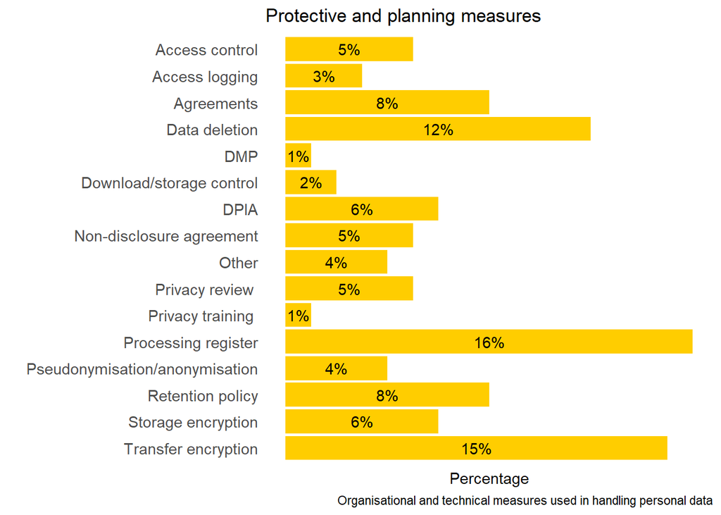

#### Veterinary Medicine

Protective measures for the Faculty of Veterinary Medicine.

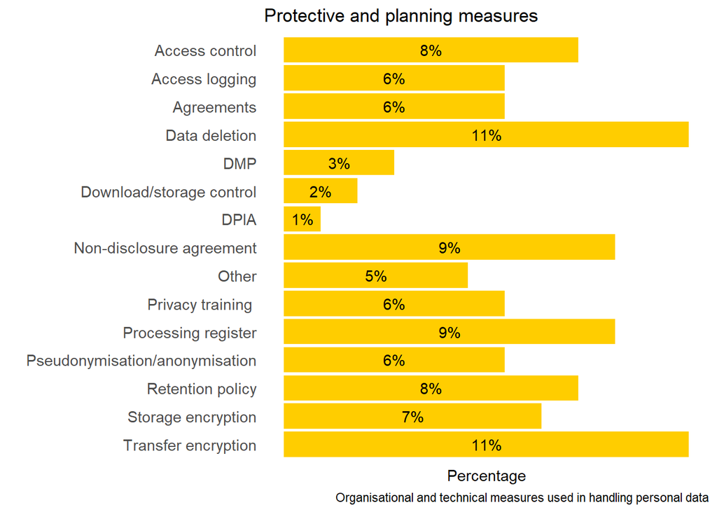

#### LEG

Protective measures for the Faculty of Law, Economics and Governance.

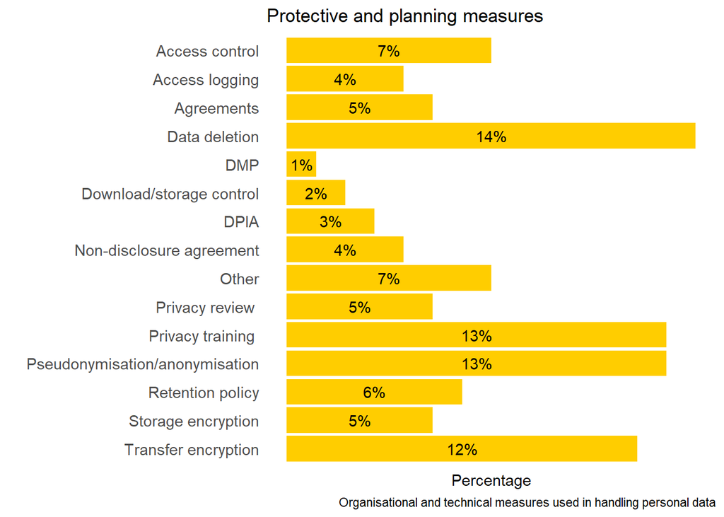

#### Geo

Protective measures for the Faculty of Geosciences.

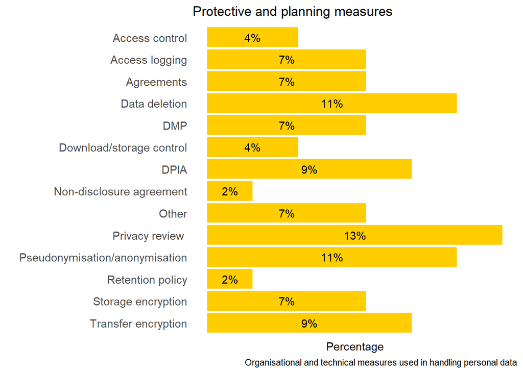

### Storage media

#### UU-wide

When working with personal data, it is important to choose a sufficiently secure storage medium. Luckily, most respondents indicated to rely on storage solutions that are provided or recommended by UU - and in most cases are indeed safe for storing personal data. Nonetheless, some respondents indicated to use non-UU solutions, including cloud solutions that UU advises against using. Several respondents also indicated that they use other storage solutions, such as those of external institutions (e.g., University Medical Center, Trimbos Institute, Central Bureau of Statistics) and repositories (e.g., DANS EASY, CLARIAH).

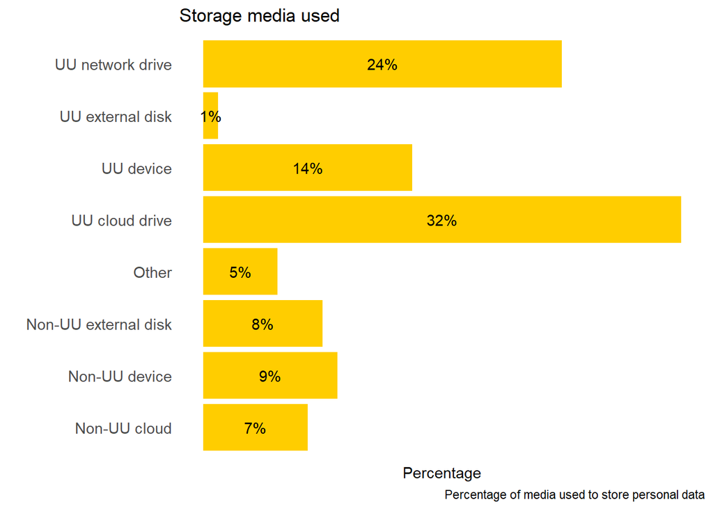

#### Science

Storage media used in the Science faculty.

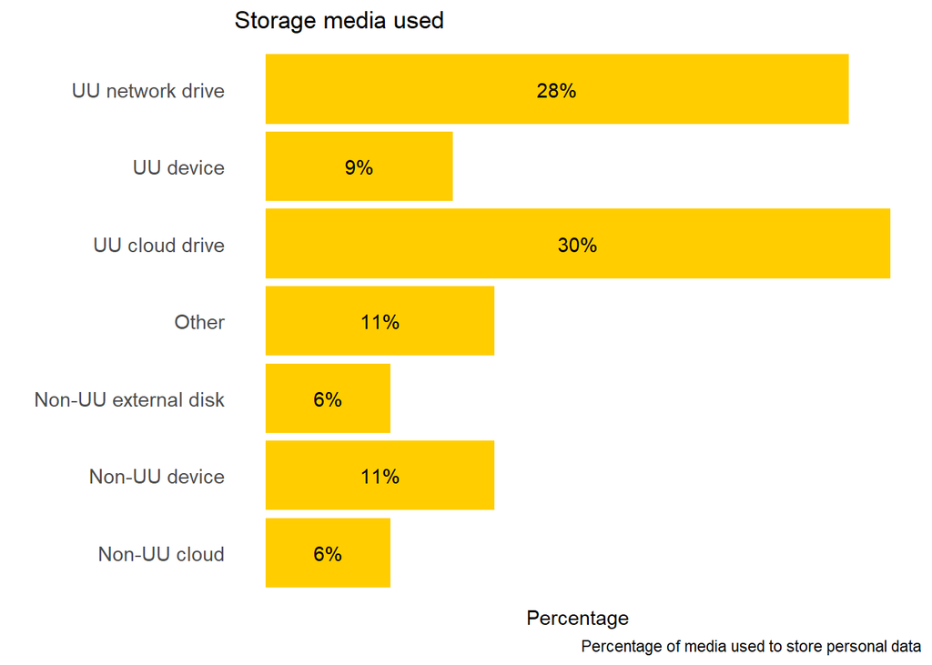

#### FBSB

Storage media used in the Faculty of Social and Behavioural Sciences.

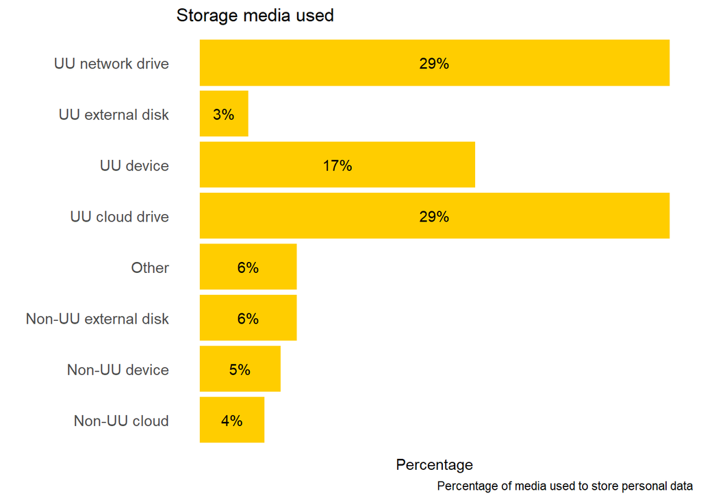

#### Humanities

Storage media used in the Faculty of Humanities.

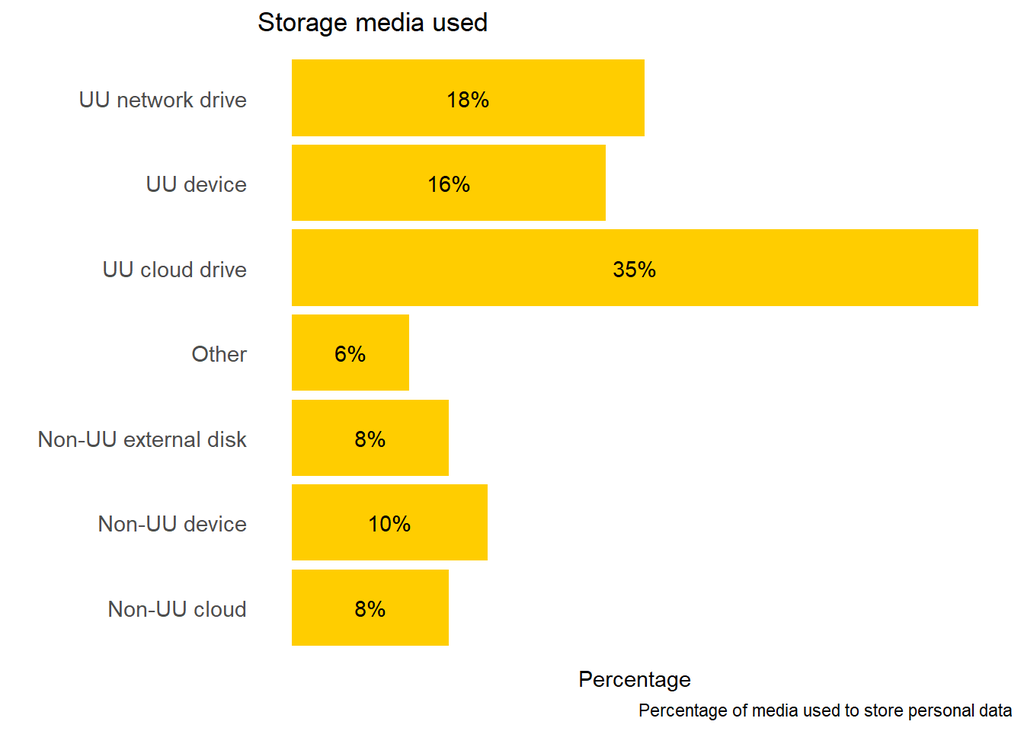